# M2.992_PAC4-Enunciat

[figure not shown]

M2.992 · Anàlisi de xarxes complexes

20251 - Màster universitari en Ciència de dades (*Data science*)

Estudis d'Informàtica, Multimèdia i Telecomunicacions

**Nom i cognoms:** Marc Cervera Rosell

**Recordatori: Verificació d'autoria mitjançant entrevista de contrast** Aquesta activitat està subjecta a la verificació de l'autoria, la qual pot incloure entrevistes de contrast, tal com es descriu en el pla docent de l'assignatura. En cas que el professorat ho consideri necessari, es podrà convocar l'estudiant per realitzar una entrevista amb l'objectiu de comprovar la correspondència entre el contingut presentat i els coneixements adquirits, així com l'autoria independent de l'activitat. Trobareu més informació en el pla docent de l'assignatura..

**Fonts bibliogràfiques i ús d’eines d’IA.** És necessari que l’estudiant indiqui totes les fonts que ha utilitzat per a l’elaboració dels diferents apartats de la PAC i de quina manera han estat utilitzades. Això inclou qualsevol ús d’eines d’IA generativa o similars, les quals estan permeses. No indicar de manera adequada els recursos utilitzats pot ser considerat plagi i penalitzat amb un suspens (D).

**Figures i representacions gràfiques** Les figures han de contenir sempre una etiqueta i ser degudament clares i informatives. Si no es compleixen aquestes condicions, les representacions, quan es demanin, es consideraran completament incorrectes. Algunes guies o exemples sobre com han de ser les figures:

- https://www.ncbi.nlm.nih.gov/pmc/articles/PMC4161295/
- https://www.quanthub.com/designing-charts-axes-and-value-labels/

Disenyar i representar de forma correcta informació gràfica és una competència transversal que s'ha d'adquirir.

Alguns punts fonamentals:

- LLegendes clares i informatives incloent-hi les seves unitats.
- El format de les línies, punts i representacions gràfiques ha de ser tan informatiu i clar com sigui possible.
- Els textos superposats sobre altres textos o sobre informació gràfica es puntuarà, en general, de manera molt negativa.

**Puntualitat en el lliurament de la PAC** Les PAC lliurades més enllà de la data límit (fins i tot amb minuts de retard) seran avaluades com a entregues realitzades en avaluació extraordinària. Es recomana, per tant, fer el lliurament amb prou antelació per prevenir possibles problemes tècnics d’última hora amb l’exportació del document, problemes de connexió, etc.

# PAC 4: Aprenentatge automàtic en grafs

En aquesta pràctica es posaran en pràctica els coneixements adquirits al mòdul 5 i, a més, servirà per repassar alguns conceptes apareguts anteriorment. També s’hi introdueixen conceptes transversals relacionats amb el *Deep Learning*.

Les **competències** que es treballaran en aquesta activitat són les següents:

1. Comprendre la problemàtica i saber aplicar les tècniques més rellevants en un escenari de predicció o classificació sobre grafs.
2. Saber dissenyar i aplicar diferents algorismes relacionats amb les *Graph Neural Networks*.

I els **resultats d’aprenentatge** esperats són:

1. Conèixer tècniques modernes de xarxes neuronals sobre grafs.
2. Conèixer el funcionament i els principals models de les GNNs.
3. Saber interpretar les mètriques d’avaluació de les GNNs.

Consideracions generals:

- Aquesta prova d’avaluació s’ha de resoldre utilitzant la llibreria `NetworkX`, `torch_geometric`, `torch` i altres llibreries importades a l’enunciat. L’ús de qualsevol **altra llibreria s’ha de justificar** en la mateixa activitat.
- Aquesta PAC s’ha de realitzar de manera **estrictament individual**. Qualsevol indici de còpia serà penalitzat amb un suspens (D) per a totes les parts implicades i amb la possible avaluació negativa de l’assignatura en la seva totalitat.
- És necessari que l’estudiant indiqui **totes les fonts** que ha utilitzat per a la realització de la PAC. En cas contrari, es considerarà que l’estudiant ha comès plagi, i serà penalitzat amb un suspens (D) i la possible avaluació negativa de l’assignatura en la seva totalitat.

Format del lliurament:

- Alguns exercicis poden suposar diversos minuts d’execució; per tant, el lliurament s’ha de fer en **format notebook** i en **format HTML**, on es vegi el codi, els resultats i els comentaris de cada exercici. Es pot exportar el notebook a HTML des del menú *File* $\to$ *Download as* $\to$ *HTML*.
- També s’haurà de lliurar el vídeo que es demana en un dels enunciats.
- Existeix un tipus de cel·la especial per allotjar text. Aquest tipus de cel·la us serà molt útil per respondre les diferents preguntes teòriques plantejades al llarg de l’activitat. Per canviar el tipus de cel·la a aquest, al menú: *Cell* $\to$ *Cell Type* $\to$ *Markdown*.

## Càrrega de llibreries

En la següent cel·la s’han de carregar totes les llibreries necessàries per a l’execució de l’activitat. Cal justificar l’ús de qualsevol llibreria addicional que no formi part del conjunt bàsic requerit.

```python
!pip install torch
```

```python
!pip install torch_geometric
```

```python
import numpy as np
import networkx as nx
import pandas as pd
import tqdm
import torch
import torch.nn as nn
import torch.nn.functional as F
from torch_geometric.nn import GATConv, SAGEConv, GINConv, global_mean_pool
from torch_geometric.loader import DataLoader
from torch_geometric.data import Dataset, Data
from torch_geometric.utils import to_networkx
import random
import copy
import matplotlib.pyplot as plt
```

## Introducció. Graph neural networks aplicades a la química i la bioinformàtica.

Si et preguntes per a què serveixen les *graph neural networks*, una resposta senzilla i directa és: per guanyar el **Premi Nobel de Química de 2024**.

- https://rseq.org/david-baker-demis-hassabis-y-john-m-jumper-premio-nobel-de-quimica-2024

Això ho van aconseguir resolent, mitjançant els models **AlphaFold** i **AlphaFold2**, un dels problemes més inabordables de la química fins al moment: predir el comportament espacial i l’estructura de les cadenes químiques a partir dels seus subcomponents. Això obre la porta a accelerar el disseny de fàrmacs específics com mai abans. Per conèixer què són els models AlphaFold (actualment en la seva tercera versió), et recomano veure el vídeo introductori següent:

- https://www.youtube.com/watch?v=gg7WjuFs8F4&t

I per conèixer una mica més un dels guardonats, a continuació tens una entrevista que li han fet fa poc temps:

- https://www.youtube.com/watch?v=-pGs0btGmgY

En aquesta PAC ens submergim en el món de la bioinformàtica de la mà de les *graph neural networks*.

## PAC

En aquesta ocasió anem a calcular alguns dels resultats que es mostren en l’article **SICGNN: structurally informed convolutional graph neural networks for protein classification** https://iopscience.iop.org/article/10.1088/2632-2153/ad979b#mlstad979bs4

**Exercici 0: Entendre graph neural networks recents: GAT, GIN i GraphSage (1.5 punts)**

**Atenció: Exercici indispensable per aprovar la PAC**

- Es recomana realitzar aquest apartat al final de la PAC, ja que durant l’exercici s’espera que aprengueu en profunditat aquests algorismes. Tanmateix, s’ha volgut anunciar al principi de la PAC perquè no es passi per alt aquest apartat fonamental. **Sense aquest apartat degudament completat i aprovat, no es corregirà la PAC.**
- **Instruccions:**
  - Elabora un **vídeo d’1 minut com a màxim** en què expliquis les principals característiques i diferències entre els algorismes **GAT**, **GraphSAGE** i **GIN**.
    - GAT: https://arxiv.org/pdf/1710.10903
    - GraphSAGE: https://arxiv.org/pdf/1706.02216
    - GIN: https://arxiv.org/pdf/1810.00826v3
  - T’has de recolzar en una o diverses diapositives o en elements interactius.
  - L’estudiant ha de ser clarament visible al vídeo juntament amb la diapositiva.
  - Les diapositives no poden contenir text. Únicament informació gràfica i paraules soltes per donar suport a aquesta informació.
  - Està prohibit llegir. Això comportaria una qualificació negativa.
  - L’àudio i el vídeo han de ser clars i d’una qualitat adequada.
  - A l’hora d’elaborar el vídeo, tingues en compte que ha de ser entenedor per a qualsevol audiència de nivell universitari (*level 3*). Es recomana veure l’exemple següent: https://www.youtube.com/watch?v=fkIvmfqX-t0
- **Lliurament del vídeo:**
  - S’ha habilitat una pàgina per al lliurament anomenada **«Entrega de la PAC4 VIDEO»**. Allà heu de pujar un vídeo en **format recomanat mp4** i amb **resolució recomanada de 720p**. El vídeo ha de pesar **menys de 50 MB**.
  - Podeu gravar-lo amb qualsevol eina que us vagi bé (per exemple, https://clipchamp.com) o bé gravar-lo mitjançant l’eina que hem habilitat en aquesta mateixa pàgina.
  - Es recomana utilitzar **Chrome**.

Les referències externes en aquesta PAC han estat citades segons els criteris generals de la norma:

UNE-ISO 690:2013. *Informació i documentació. Directrius per a la redacció de referències bibliogràfiques i de cites de recursos d'informació.*

Els criteris generals de citació han estat trobats a:

*Estil ISO 690* [en línia] [consulta: 29 de desembre de 2025]. Disponible a: https://biblioteca.uoc.edu:8080/ca/plana/Estil-ISO-690/

**Exercici 1: Anàlisi preliminar de les dades (1 punt)**

Com és habitual en aquests casos, comencem realitzant una anàlisi preliminar de les dades. Per a això processarem els conjunts de dades **PROTEINS**, **DD** i **ENZYMES** (proporcionats juntament amb la PAC) i es demana el següent:

- **1.1** Carrega les dades i processa-les adequadament per representar la **Taula 1. *Statistics of benchmark protein-graph-classification datasets*** de l’article https://iopscience.iop.org/article/10.1088/2632-2153/ad979b#mlstad979bs4. S’ha de mostrar una taula amb un format tan semblant com sigui possible al del *paper*. Fes les suposicions necessàries per determinar si els grafs són dirigits o no dirigits. Si tens dubtes, comenta’ls al fòrum amb els teus companys/es. Si hi ha alguna discrepància, indica-la. *(0,5 punts)*
- **1.2** Fes una breu anàlisi únicament del conjunt de dades **PROTEINS**. Utilitza les mètriques de **grau mitjà** i de **longitud mitjana del camí més curt** per determinar si existeix una diferència significativa entre els grafs etiquetats com a **classe 1** i **classe 2**. Representa els resultats en una o diverses gràfiques. Escriu les teves conclusions en **dues línies**. *(0,5 punts)*

**El graf és dirigit o no dirigit?**

En comprovar els fitxer de les arestes, s'ha pogut observar que per a una mateixa aresta sempre hi ha el seu invers. És a dir, per cada aresta (u,v) existeix la seva inversa (v,u). A més, ens els fitxers de les arestes no hi ha res que indiqui o doni a entendre que la direcció de les arestes importa.

Donats aquests fets, es suposa que els grafs són no dirigits.

**Exercici 1.1**

**Càrrega fitxers DD**

```python
dd_a = pd.read_table("DD/DD_A.txt", sep=",", header=None) # Bibliografia: [Ref.1] i [Ref.2]
dd_a.rename(columns={0: "Node_id1"}, inplace=True) # Bibliografia: [Ref.3]
dd_a.rename(columns={1: "Node_id2"}, inplace=True) # Bibliografia: [Ref.3]

dd_graph_indicator = pd.read_table("DD/DD_graph_indicator.txt", sep=",", header=None) # Bibliografia: [Ref.1] i [Ref.2]
dd_graph_indicator.rename(columns={0: "Graph_id"}, inplace=True) # Bibliografia: [Ref.3]

dd_graph_labels = pd.read_table("DD/DD_graph_labels.txt", sep=",", header=None) # Bibliografia: [Ref.1] i [Ref.2]
dd_graph_labels.rename(columns={0: "Class_label"}, inplace=True) # Bibliografia: [Ref.3]

dd_node_labels = pd.read_table("DD/DD_node_labels.txt", sep=",", header=None) # Bibliografia: [Ref.1] i [Ref.2]
dd_node_labels.rename(columns={0: "Node_id"}, inplace=True) # Bibliografia: [Ref.3]
```

**Càrrega fitxers ENZYMES**

```python
enzymes_a = pd.read_table("ENZYMES/ENZYMES_A.txt", sep=",", header=None) # Bibliografia: [Ref.1] i [Ref.2]
enzymes_a.rename(columns={0: "Node_id1"}, inplace=True) # Bibliografia: [Ref.3]
enzymes_a.rename(columns={1: "Node_id2"}, inplace=True) # Bibliografia: [Ref.3]

enzymes_graph_indicator = pd.read_table("ENZYMES/ENZYMES_graph_indicator.txt", sep=",", header=None) # Bibliografia: [Ref.1] i [Ref.2]
enzymes_graph_indicator.rename(columns={0: "Graph_id"}, inplace=True) # Bibliografia: [Ref.3]

enzymes_graph_labels = pd.read_table("ENZYMES/ENZYMES_graph_labels.txt", sep=",", header=None) # Bibliografia: [Ref.1] i [Ref.2]
enzymes_graph_labels.rename(columns={0: "Class_label"}, inplace=True) # Bibliografia: [Ref.3]

enzymes_node_attributes = pd.read_table("ENZYMES/ENZYMES_node_attributes.txt", sep=",", header=None) # Bibliografia: [Ref.1] i [Ref.2]

enzymes_node_labels = pd.read_table("ENZYMES/ENZYMES_node_labels.txt", sep=",", header=None) # Bibliografia: [Ref.1] i [Ref.2]
enzymes_node_labels.rename(columns={0: "Node_id"}, inplace=True) # Bibliografia: [Ref.3]
```

**Càrrega fitxers PROTEINS**

```python
proteins_a = pd.read_table("PROTEINS/PROTEINS_A.txt", sep=",", header=None) # Bibliografia: [Ref.1] i [Ref.2]
proteins_a.rename(columns={0: "Node_id1"}, inplace=True) # Bibliografia: [Ref.3]
proteins_a.rename(columns={1: "Node_id2"}, inplace=True) # Bibliografia: [Ref.3]

proteins_graph_indicator = pd.read_table("PROTEINS/PROTEINS_graph_indicator.txt", sep=",", header=None) # Bibliografia: [Ref.1] i [Ref.2]
proteins_graph_indicator.rename(columns={0: "Graph_id"}, inplace=True) # Bibliografia: [Ref.3]

proteins_graph_labels = pd.read_table("PROTEINS/PROTEINS_graph_labels.txt", sep=",", header=None) # Bibliografia: [Ref.1] i [Ref.2]
proteins_graph_labels.rename(columns={0: "Class_label"}, inplace=True) # Bibliografia: [Ref.3]

proteins_node_attributes = pd.read_table("PROTEINS/PROTEINS_node_attributes.txt", sep=",", header=None) # Bibliografia: [Ref.1] i [Ref.2]

proteins_node_labels = pd.read_table("PROTEINS/PROTEINS_node_labels.txt", sep=",", header=None) # Bibliografia: [Ref.1] i [Ref.2]
proteins_node_labels.rename(columns={0: "Node_label"}, inplace=True) # Bibliografia: [Ref.3]
```

**Extracció de dades per la taula**

```python
# -- DD --
num_graphs_dd = dd_graph_labels.shape[0]
num_classes_dd = dd_graph_labels["Class_label"].nunique()
# - Max nodes i mitja -
ids_dd = dd_graph_indicator["Graph_id"].tolist() # Bibliografia: [Ref.4]
dict_graph_nodes_dd = {} # {graph_id: count_nodes}
for id_val in ids_dd:
    if id_val in dict_graph_nodes_dd:
        dict_graph_nodes_dd[id_val] += 1
    else:
        dict_graph_nodes_dd[id_val] = 1
max_nodes_dd = max(dict_graph_nodes_dd.values())
average_nodes_dd = sum(dict_graph_nodes_dd.values()) / len(dict_graph_nodes_dd)
average_edges_dd = (len(dd_a) / num_graphs_dd) / 2 # Dividir per 2 per cada aresta apareix 2 cops
```

```python
# -- ENZYMES --
num_graphs_enzymes = enzymes_graph_labels.shape[0]
num_classes_enzymes = enzymes_graph_labels["Class_label"].nunique()
# - Max nodes i mitja -
ids_enzymes = enzymes_graph_indicator["Graph_id"].tolist() # Bibliografia: [Ref.4]
dict_graph_nodes_enzymes = {} # {graph_id: count_nodes}
for id_val in ids_enzymes:
    if id_val in dict_graph_nodes_enzymes:
        dict_graph_nodes_enzymes[id_val] += 1
    else:
        dict_graph_nodes_enzymes[id_val] = 1
max_nodes_enzymes = max(dict_graph_nodes_enzymes.values())
average_nodes_enzymes = sum(dict_graph_nodes_enzymes.values()) / len(dict_graph_nodes_enzymes)
average_edges_enzymes = (len(enzymes_a) / num_graphs_enzymes) / 2 # Dividir per 2 per cada aresta apareix 2 cops
```

```python
# -- PROTEINS --
num_graphs_proteins = proteins_graph_labels.shape[0]
num_classes_proteins = proteins_graph_labels["Class_label"].nunique()
# - Max nodes i mitja -
ids_proteins = proteins_graph_indicator["Graph_id"].tolist() # Bibliografia: [Ref.4]
dict_graph_nodes_proteins = {} # {graph_id: count_nodes}
for id_val in ids_proteins:
    if id_val in dict_graph_nodes_proteins:
        dict_graph_nodes_proteins[id_val] += 1
    else:
        dict_graph_nodes_proteins[id_val] = 1
max_nodes_proteins = max(dict_graph_nodes_proteins.values())
average_nodes_proteins = sum(dict_graph_nodes_proteins.values()) / len(dict_graph_nodes_proteins)
average_edges_proteins = (len(proteins_a) / num_graphs_proteins) / 2 # Dividir per 2 per cada aresta apareix 2 cops
```

**Creació i printat de la taula**

```python
# Bibliografia: [Ref.5]
stats = {"Dataset": ["DD", "ENZYMES", "PROTEINS"], "# Grpahs": [num_graphs_dd, num_graphs_enzymes, num_graphs_proteins],
        "# Classes": [num_classes_dd, num_classes_enzymes, num_classes_proteins], "# Nodes": [round(average_nodes_dd, 2),
                                                                                              round(average_nodes_enzymes, 2),
                                                                                              round(average_nodes_proteins, 2)],
        "# Edges": [round(average_edges_dd, 2), round(average_edges_enzymes, 2), round(average_edges_proteins, 2)],
         "# Max nodes": [max_nodes_dd, max_nodes_enzymes, max_nodes_proteins]}
df_stats = pd.DataFrame(stats)
```

```python
df_stats.style.format({"# Nodes": "{:.2f}", "# Edges": "{:.2f}"}).hide(axis='index') # Bibliografia: [Ref.6] -> Ús 1
```

| Dataset | # Grpahs | # Classes | # Nodes | # Edges | # Max nodes |
| --- | --- | --- | --- | --- | --- |
| DD | 1178 | 2 | 284.32 | 715.66 | 5748 |
| ENZYMES | 600 | 6 | 32.63 | 62.14 | 126 |
| PROTEINS | 1113 | 2 | 39.06 | 72.82 | 620 |

**Exercici 1.2**

**Creació de grafs**

```python
graphs = {graph_id: nx.Graph() for graph_id in range(1, num_graphs_proteins + 1)} # +1 perque comencem a crear a aprtir del graf 1 i no del graf 0
graphs_nodes = {} # Bibliografia: [Ref.6] -> Ús 2
# - Afegir nodes a cad graph -
for index, graph_id in proteins_graph_indicator.iterrows(): # Bibliografia: [Ref.7]
    graph = graphs[graph_id.iloc[0]] # Apunt 1
    graph.add_node(index + 1)
    if index + 1 not in graphs_nodes: # Bibliografia: [Ref.6] -> Ús 2
        graphs_nodes[index + 1] = graph_id.iloc[0]

# - Afegir arestes -
# Bibliografia: [Ref.6] -> Ús 2
for index, nodes in proteins_a.iterrows():
    node1, node2 = nodes.iloc[0], nodes.iloc[1]
    graph_to_add_edge = graphs_nodes[node1]
    actual_graph = graphs[graph_to_add_edge]
    if not actual_graph.has_edge(node1, node2):
        actual_graph.add_edge(node1, node2)
```

**Apunt 1:** Si només es posa:

```
graph_id[0]
```

salta un warning de futur amb el suggeriment de correcció.

**Mètriques**

```python
# -- Grau mitjà --
average_degree_dict = {} # {graph_id: average_degree}
for graph_id, graph in graphs.items():
    graph_nodes = graph.number_of_nodes()
    average_degree = sum(dict(graph.degree()).values()) / graph_nodes # Bibliografia: [Ref.8]
    average_degree_dict[graph_id] = average_degree
```

```python
# -- longitud mitjana del camí més curt --
avg_shortest_path_length_dict = {} # {graph_id: average_shortest_path_lenght de la component connexa mes gran}
for graph_id, graph in graphs.items():
    # Es calcula la component connexa mes gran com a sistema de seguretat per si el graf sencer no fos connex.
    biggest_connected_component = max(nx.connected_components(graph), key=len) # Bibliografia: [Ref.8]
    subgraph_biggest_connected_component = graph.subgraph(biggest_connected_component) # Bibliografia: [Ref.9]
    avg_shortest_path_length_dict[graph_id] = nx.average_shortest_path_length(subgraph_biggest_connected_component) # Bibliografia: [Ref.10]
```

**Gràfiques**

```python
# -- Mapping de cada grag amb la seva classe --
map_class_graph_id = {} # {graph_id: classe}
for index, graph_class in proteins_graph_labels.iterrows():
    map_class_graph_id[index + 1] = graph_class.iloc[0] # Apunt 1

# -- Saber quins elements de average_degree_dict i avg_shortest_path_length_dict son de cada classe --
average_degree_class1 = []
average_degree_class2 = []
avg_shortest_path_length_class1 = []
avg_shortest_path_length_class2 = []
for graph_id in average_degree_dict.keys():
    if map_class_graph_id[graph_id] == 1:
        average_degree_class1.append(average_degree_dict[graph_id])
        avg_shortest_path_length_class1.append(avg_shortest_path_length_dict[graph_id])
    else:
        average_degree_class2.append(average_degree_dict[graph_id])
        avg_shortest_path_length_class2.append(avg_shortest_path_length_dict[graph_id])
```

**Apunt 2:**

En la línia:

```
plt.boxplot([average_degree_class1, average_degree_class2], labels=["Class 1", "Class 2"])
```

Salta un warning conforme el paràmetre *labels* ha estat renombrat a *tick_labels*

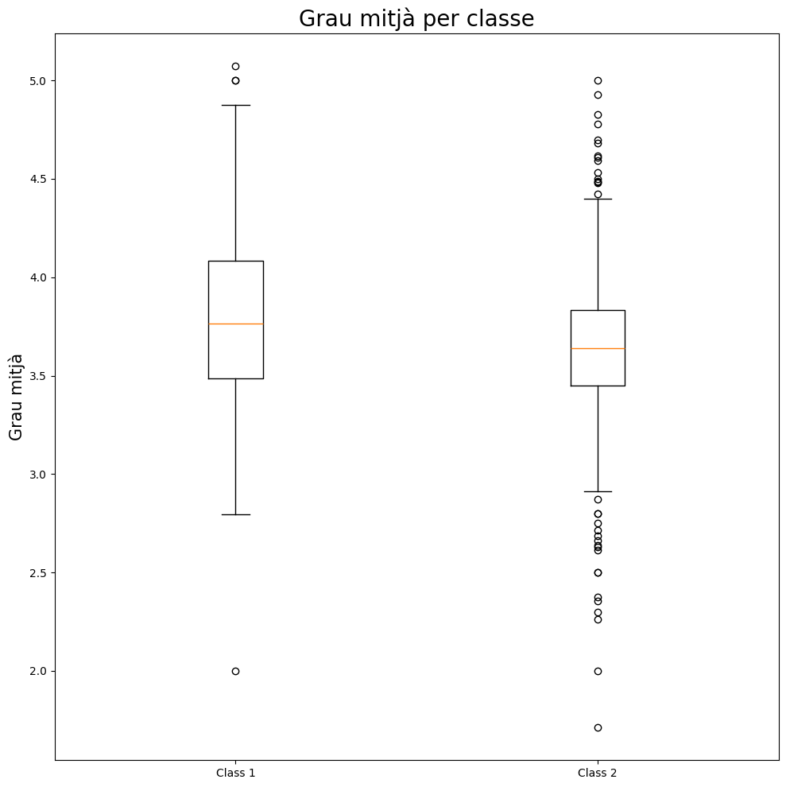

```python
# -- Gràfic grau mitjà --
# Bibliografia: [Ref.11]
plt.figure(figsize=(10,10))
plt.boxplot([average_degree_class1, average_degree_class2], tick_labels=["Class 1", "Class 2"]) # Apunt 2 i # Bibliografia: [Ref.12]
plt.title("Grau mitjà per classe", fontsize=20)
plt.ylabel("Grau mitjà", fontsize=15)
plt.tight_layout()
plt.show()
```

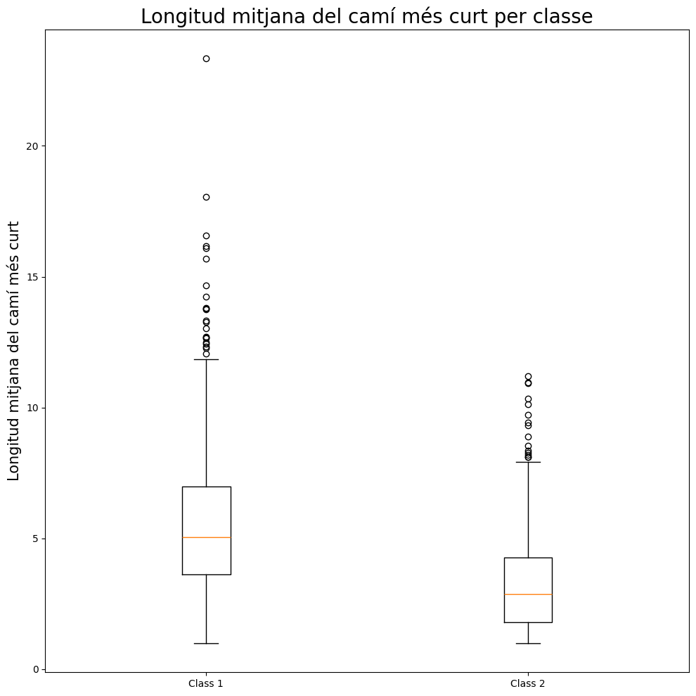

```python
# -- Gràfic longitud mitjana del camí més curt --
# Bibliografia: [Ref.11]
plt.figure(figsize=(10,10))
plt.boxplot([avg_shortest_path_length_class1, avg_shortest_path_length_class2], tick_labels=["Class 1", "Class 2"]) # Apunt 2 i # Bibliografia: [Ref.12]
plt.title("Longitud mitjana del camí més curt per classe", fontsize=20)
plt.ylabel("Longitud mitjana del camí més curt", fontsize=15)
plt.tight_layout()
plt.show()
```

**Conclusions**

La classe 1 té un grau mitjà una superior i camins més llargs amb casos extrems de graus mitjans i camins molt grans i 1 cas de grau mitjà molt petit. La classe 2, té un grau mitjà més petit amb casos extrems de graus mitjans molt grans o molt petits. També té camins més curts i valors extrems de camins molt llargs.

**Referències externes:**

[Ref.1] -- *How to Read Text Files with Pandas?* [en línia] [consulta: 29 de desembre de 2025]. Disponible a: https://www.geeksforgeeks.org/python/how-to-read-text-files-with-pandas/ **--> Web que explica com llegir fitxers .txt amb Pandas.**

[Ref.2] -- *pandas.read_table* [en línia] [consulta: 29 de desembre de 2025]. Disponible a: https://pandas.pydata.org/docs/reference/api/pandas.read_table.html **--> Documentació oficial de la funció per llefir fitxers generals delimitats.**

[Ref.3] -- *pandas.DataFrame.rename* [en línia] [consulta: 29 de desembre de 2025]. Disponible a: https://pandas.pydata.org/docs/reference/api/pandas.DataFrame.rename.html **--> Documentació oficial de la funció per a renombrar.**

[Ref.4] -- *Get Unique Values from a Column in Pandas DataFrame* [en línia] [consulta: 29 de desembre de 2025]. Disponible a: https://www.geeksforgeeks.org/python/get-unique-values-from-a-column-in-pandas-dataframe/ **--> Web que explica com obtenir i/o comptar els valors únics d'una columna d'un DataFrame.**

[Ref.5] -- *pandas.DataFrame* [en línia] [consulta: 29 de desembre de 2025]. Disponible a: https://pandas.pydata.org/docs/reference/api/pandas.DataFrame.html **--> Documentació oficial de la funció per a crear un dataframe.**

[Ref.6] -- GOOGLE. *Gemini* [programari]. Versió Gemini 3 Flash. 2025.

**Ús 1 --> S'ha demanat com treure per pantalla un dataframe sense que es vegin els índex (Per fer que la taula s'assembli el més possible a la de l'article) i sense que apareguin 0 extra als decimals**

**Ús 2 --> S'ha demanat a l'eina optimitzar el procès de afegir les arestes ja que la versió inicial era extremadament lenta.**

**Ús 3 --> Utilitzat per confirmar si *out_channels* es la mida de la capa.**

**Ús 4 --> Segons explica l'eina el *in_channels* s'ha de definir com 3 perquè el fitxer PROTEINS_node_labels.txt té tres valors diferents, és a dir que cada node pot tenir una label 0, 1 o 2. Perquè la xarxa neuronal pugui processar aquestes labels, es codifiquen mitjançant *one-hot encoding* convertint cada etiqueta en un vector de dimensió 3. Aquest serà el vector que alimentarà la capa GATConv.**

**S'utilitza la codificació *one-hot* perquè si introduissim les labels de cada node (0, 1 o 2) com un valor escalar el model interpretaria que la label 2 té més pes que la label 0. Al transformar-les en un vector de dimensió 3 es garanteix que cada label es tractada de manera igual.**

**Ús 5 --> S'ha preguntat es pot entrenar un model torch geometric amb dades de networkx. L'eina explica que s'han de convertir a objectes Data.**

**Ús 6 --> Utilitzat per saber com afegir la classe de cada graf i perquè cal restar 1. L'ajust de restar 1 a la classe, es necessàri perquè, sinó, la funció de pèrdua CrossEntropyLoss interpretaria que hi ha 3 (0, 1 i 2) classes en comptes de dues.**

**Ús 7 --> Utilitzat per saber a que es refereix l'article original de GAT ([Ref.19] i [24] de l'article de la PAC) quan parla de *regularization*. L'eina explica que regularizazation es el *Weight Decay***

**Ús 8 --> Utilitzat per saber com fer que el model tardi menys en entrenar-se.**

**Ús 9 --> Utilitzat per adaptar el calcul de la pèrdua mitjana en una època a la PAC.**

**Ús 10 --> Utilitzat per saber com calcular la diferència relativa entre dos nombres.**

**Ús 11 --> Utilitzat per saber d'on treure les dades per al conjunt de validació.**

**Ús 12 --> Utilitzat per adaptar la taula de la imatge d'acontinuació al format de la taula de l'article.**

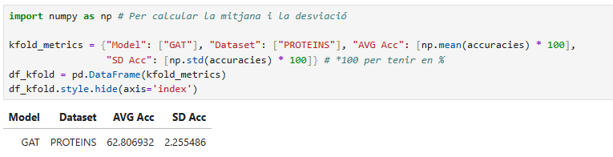

[Ref.7] -- *How can I iterate over rows in a Pandas DataFrame?* [en línia] [consulta: 29 de desembre de 2025]. Disponible a: https://stackoverflow.com/questions/16476924/how-can-i-iterate-over-rows-in-a-pandas-dataframe **--> Fil de Stack OVerflow que explica com iterar un dataframe de Pandas**

[Ref.8] -- *Graph.degree* [en línia] [consulta: 29 de desembre de 2025]. Disponible a: https://networkx.org/documentation/stable/reference/classes/generated/networkx.Graph.degree.html#networkx.Graph.degree **--> Documentació oficial de la funció per a saber el node d'un grau.**

[Ref.9] -- *Graph.subgraph* [en línia] [consulta: 29 de desembre de 2025]. Disponible a: https://networkx.org/documentation/stable/reference/classes/generated/networkx.Graph.subgraph.html **--> Documentació oficial per a crear un subgraf.**

[Ref.10] -- *average_shortest_path_length* [en línia] [consulta: 29 de desembre de 2025]. Disponible a: https://networkx.org/documentation/stable/reference/algorithms/generated/networkx.algorithms.shortest_paths.generic.average_shortest_path_length.html **--> Documentació oficial de la funció per a obtenir la longitud mitjana del camí més curt d'un graf.**

[Ref.11] -- *Data Viz Project* [en línia] [consulta: 29 de desembre de 2025]. Disponible a: https://datavizproject.com/ **--> Web que explica l'ús de diferents tipus de grafics.**

[Ref.12] -- *Box Plot in Python using Matplotlib* [en línia] [consulta: 29 de desembre de 2025]. Disponible a: https://www.geeksforgeeks.org/data-visualization/box-plot-in-python-using-matplotlib/ **--> Web que explica com crear un diagrama de caixes amb matplotlib.**

**Exercici 2: Graph Attention Network (GAT) (3,5 punts)**

A partir d’ara, a la PAC, únicament treballarem amb el conjunt de dades **PROTEINS**. Tenint en compte que l’objectiu serà entrenar una xarxa neuronal de grafs per a la classificació de proteïnes, es demana:

- **2.1.** Identifica a l’article com és l’estructura del model **GAT** d’una única capa que proposen i construeix el teu model. Tingues en compte que, a més de la capa GAT, hauràs d’afegir més elements a la teva arquitectura (*dropout*, *fully connected*, etc.). Utilitza les llibreries **PyTorch** i **torch_geometric**. El nombre de paràmetres de la capa GAT ha de ser tal que concordi amb el millor resultat corresponent a la **Figura 6. *Performance comparison with changes in the dimensions of each GNN layer...***. És possible que no tota la informació estigui ben explicada a l’article; assumeix les hipòtesis que consideris i explica-les. Imprimeix i mostra el nombre de paràmetres entrenables de la capa GAT. *(1 punt).*
- **2.2.** Prepara les funcions d’entrenament i els optimitzadors; tria una mètrica de *loss* adequada. Fes un primer *split* de *train/val/test* i realitza un entrenament. Tria el millor *checkpoint* en funció dels resultats del *split* de validació. Finalment, mostra els resultats sobre el *split* de test. Compara els resultats amb els que es mostren a la taula **Taula 2. *Performance comparison of representative GNNs***. Una diferència relativa inferior al 10% és acceptable. Si els teus resultats difereixen més, revisa l’exercici, ajusta la configuració de les capes del model, els hiperparàmetres, etc. Pot ser que et sorgeixin dubtes a l’hora de prendre decisions; comenta’ls al fòrum amb els teus companys/es, etc. *(1 punt).*
- **2.3.** A l’article s’esmenta que utilitzen un **k-fold**. Implementa’l de manera que construeixis els conjunts de dades de *train*, validació i test. En lloc d’un k-fold de 10 com a l’article, utilitza un **k-fold de 5**. Assumeix les hipòtesis que consideris. Ara sí, obtingues resultats per al conjunt de dades **PROTEINS** per al model **GAT** de la **Taula 2. *Performance comparison of representative GNNs***. Representa una taula com la de l’article amb els resultats que tens fins ara. *(1,5 punts)*

**Solució**

**Exercici 2.1**

```python
# Estructura segons article (figura 2) = GNN (GATConv) -> Readout (utilitza max_pooling com GraphSAGE) -> Classifier
# Bibliografia: [Ref.13] i [Ref.14]
from torch_geometric.nn import global_max_pool # Per realitzar el max_pooling com diu l'article
class GATProteins(torch.nn.Module):
    def __init__(self):
        super().__init__()
        self.gat = GATConv(3, 64)  # Bibliografia: [Ref.15]
        self.dropout = torch.nn.Dropout(p=0.3)  # Bibliografia: [Ref.16]
        self.fc = torch.nn.Linear(64, 2) # Bibliografia: [Ref.17] [Ref.18]
    def forward(self, data):
        x, edge_index, batch = data.x, data.edge_index, data.batch
        x = self.gat(x, edge_index)
        x = F.elu(x) # Bibliografia: [Ref.19]
        x = self.dropout(x)
        x = global_max_pool(x, batch) # Bibliografia: [Ref.20]
        x = self.fc(x)
        return x
model = GATProteins()
get_params = sum(p.numel() for p in model.gat.parameters() if p.requires_grad) # Bibliografia: [Ref.21]
print(f"Num parametres = {get_params}")
```

```
Num parametres = 384
```

**Hipòtesis**

- Funció d'activació ELU $\rightarrow$ En el paper original del GAT (referència [24] del paper de l'enunciat), s'explica com s'utilitza aquesta funció d'activació.
- READOUT $\rightarrow$ En el paper de l'enunciat s'especifica explicitament que per a obtenir el embedding sencer s'utilitza max-pooling, similar al GraphSAGE, tal i com es mostra en l'equació 8. En el paràgraf predecessor a la definició de l'equació 8 s'especifica "*[...] Because GraphSAGE was not tested on graph-classification tasks in the original paper, we applied the max-pooling global READOUT function*."
- Segons la imatge 6 el millor resultat (major accuracy) es dona quan la dimensió de cada capa es de 64 en el model GAT. Per aquest motiu es tria 64 com a *out_cannels*. # Bibliografia: [Ref.6] -> Ús 3
- El fitxer PROTEINS_node_labels.txt té 3 categories diferents (0, 1 i 2). Per aquest motiu es tria 3 com a *in_channels*. # Bibliografia: [Ref.6] -> Ús 4
- El fitxer PROTEINS_graph_labels.txt té valors 1 i 2 confirmant que un graf nomes pot perterànyer a 2 classes. Per aquest motiu s'estableix el *out_features* de torch.nn.Linear a 2.

**Exercici 2.2**

**Afegir el node label codificat amb one-hot**

```python
mapping_node_label = {} # {node_id: label}
for index, node_label in proteins_node_labels.iterrows():
    mapping_node_label[index + 1] = node_label.iloc[0]

for node_id, label in mapping_node_label.items():
    if label == 0:
        mapping_node_label[node_id] = [1,0,0]
    elif label == 1:
        mapping_node_label[node_id] = [0,1,0]
    elif label == 2:
        mapping_node_label[node_id] = [0,0,1]
```

```python
graphs = {graph_id: nx.Graph() for graph_id in range(1, num_graphs_proteins + 1)} # +1 perque comencem a crear a aprtir del graf 1 i no del graf 0
graphs_nodes = {} # Bibliografia: [Ref.6] -> Ús 2
# - Afegir nodes a cad graph -
for index, graph_id in proteins_graph_indicator.iterrows(): # Bibliografia: [Ref.7]
    graph = graphs[graph_id.iloc[0]] # Apunt 1
    graph.add_node(index + 1, x=mapping_node_label[index + 1])
    if index + 1 not in graphs_nodes: # Bibliografia: [Ref.6] -> Ús 2
        graphs_nodes[index + 1] = graph_id.iloc[0]

# - Afegir arestes -
# Bibliografia: [Ref.6] -> Ús 2
for index, nodes in proteins_a.iterrows():
    node1, node2 = nodes.iloc[0], nodes.iloc[1]
    graph_to_add_edge = graphs_nodes[node1]
    actual_graph = graphs[graph_to_add_edge]
    if not actual_graph.has_edge(node1, node2):
        actual_graph.add_edge(node1, node2)
```

**Afegir la label de graf i passar les dades de networkx a torch_geometric.data.Data**

```python
# Conversió de networkx a PyG geometric --> # Bibliografia: [Ref.6] -> Ús 5
from torch_geometric.utils.convert import from_networkx # Per convertir els elements a torch_geometric.data.Data
dataset_torch_geom = [] # Necessàri per entrenar el model
for graph_id, graph in graphs.items():
    data = from_networkx(graph) # Bibliografia: [Ref.22]
    graph_label = map_class_graph_id[graph_id] - 1 # Bibliografia: [Ref.6] -> Ús 6 i [Ref.26]
    data.y = torch.tensor([graph_label], dtype=torch.long)
    dataset_torch_geom.append(data)
```

**Splits de train/val/test + DataLoader**

```python
# 80% per train, 10% per validation i 10% per test
# Bibliografia: [Ref.23]
train_len = int(len(dataset_torch_geom) * 0.8)
validation_len = int(len(dataset_torch_geom) * 0.1)
test_len = len(dataset_torch_geom) - train_len - validation_len
train_set, validation_set, test_set = torch.utils.data.random_split(dataset_torch_geom, [train_len, validation_len, test_len])
train_dataloader = DataLoader(train_set, batch_size=32, shuffle=True)
validation_dataloader = DataLoader(validation_set, batch_size=32, shuffle=True)
test_dataloader = DataLoader(test_set, batch_size=32, shuffle=True)
```

**Optimitzador**

```python
model = GATProteins()
optimizer = torch.optim.Adam(model.parameters(), lr=0.0005, weight_decay=0.001) # Bibliografia: [Ref.19], [Ref.24] i [Ref.6] -> Ús 7
loss_function = torch.nn.CrossEntropyLoss() # Bibliografia: [Ref.19], [Ref.25] i [Ref.26]
```

**Entrenament i avaluació**

```python
# Bibliografia: [Ref.6] -> Ús 8
training_place = torch.device('cuda' if torch.cuda.is_available() else 'cpu')
model = model.to(training_place)
# Bibliografia: [Ref.27], [Ref.28] i [Ref.6] -> Ús 9
def train():
    model.train()
    total_loss = total_examples = 0
    for data in train_dataloader:
        data = data.to(training_place)
        data.x = data.x.float()
        optimizer.zero_grad()
        out = model(data)
        loss = loss_function(out, data.y)
        loss.backward()
        optimizer.step()
        batch = data.y.size(0)
        total_loss += loss.item() * batch
        total_examples += batch
    return total_loss / total_examples
```

```python
# Bibliografia: [Ref.28]
def validation(loader):
    model.eval()
    correct = 0
    for data in loader:
        data = data.to(training_place) # Bibliografia: [Ref.6] -> Ús 8
        data.x = data.x.float()
        out = model(data)
        pred = out.argmax(dim=1)
        correct += int((pred == data.y).sum())
    return correct / len(loader.dataset)
```

```python
epochs = 300 # Bibliografia: [Ref.19]
best_checkpoint = 0
for epoch in tqdm.auto.trange(1, epochs + 1): # epochs + 1 perque la funció actuca amb rang obert al final -> [inici, final)
    loss = train()
    validation_acc = validation(validation_dataloader)
    if validation_acc > best_checkpoint:
        best_checkpoint = validation_acc
        torch.save(model.state_dict(), "best_model.pth") # Bibliografia: [Ref.29]
```

**Testing**

```python
model.load_state_dict(torch.load("best_model.pth")) # Bibliografia: [Ref.29]
test_acc = validation(test_dataloader)
print(f"Accuracy del conjunt de testing: {test_acc*100}%")
```

```
Accuracy del conjunt de testing: 70.53571428571429%
```

IMPORTANT:

La taula 2 de l'article *Performance comparison of representative GNNs and SICGNN models using stratified 10-fold cross-validation[...]*. És a dir les dades son el resultat de entrenar el model 10 cops, per tant, les dades de la taula son la mitjana i la desviació dels 10 experiments. En el cas de l'exercici de la PAC, l'enunciat només demana _[...] Fes un primer split de train/val/test i realitza un entrenament [...]_Per tant, en només haver realitzat l'entrenament 1 cop es compara directament la accuracy obtinguda en la PAC i la mitjana dels 10 experiments de l'article.

En la següent imatge es pot observar el millor resultat obtingut:

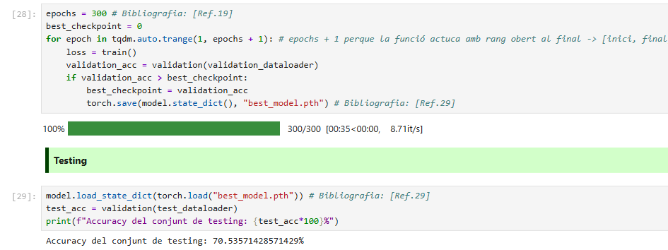

Amb un 70.54% es compleix la restricció de la diferència relativa del 10% de l'enunciat.

# Bibliografia: [Ref.6] --> Ús 10

Diferència relativa (%) = $\frac{\mid valor1 - valor2 \mid}{(valor1 + valor2) /2}$ * 100 = $\frac{\mid 70.54 - 73.989 \mid}{(70.54 + 73.989) /2}$ * 100 $\approx$ 4.77%

**Exercici 2.3**

**Implementació KFold**

```python
# Bibliografia: [Ref.30]
def train2(model, train_dataloader, optimizer, epoch):
    model.train()
    for data in train_dataloader:
        data = data.to(training_place)
        data.x = data.x.float()
        optimizer.zero_grad()
        out = model(data)
        loss = loss_function(out, data.y)
        loss.backward()
        optimizer.step()

def validation2(model, loader):
    model.eval()
    correct = 0
    for data in loader:
        data = data.to(training_place) # Bibliografia: [Ref.6] -> Ús 8
        data.x = data.x.float()
        out = model(data)
        pred = out.argmax(dim=1)
        correct += int((pred == data.y).sum())
    return correct / len(loader.dataset)
```

```python
# Bibliografia: [Ref.30]
from sklearn.model_selection import KFold # Per fer els folds # Bibliografia: [Ref.31]

kfold = KFold(n_splits=5, shuffle=True, random_state=42)
accuracies = []
epochs = 300

for fold, (train_ids, test_ids) in enumerate(kfold.split(dataset_torch_geom)):
    print(f"Fold {fold}")
    # -- DataLoader per la fold --
    # - Longituds -
    train_len = int(len(dataset_torch_geom) * 0.8)
    validation_len = int(len(dataset_torch_geom) * 0.1)
    test_len = len(dataset_torch_geom) - train_len - validation_len
    # - Split - # Bibliografia: [Ref.6] -> Ús 11
    test_set = [dataset_torch_geom[i] for i in test_ids]
    train_validation_set = [dataset_torch_geom[i] for i in train_ids]
    validation_set_len = (len(train_validation_set) * 10) // 100 # 10% per al set de validació
    train_set = train_validation_set[validation_set_len:]
    validation_set = train_validation_set[:validation_set_len]
    # - DataLoaders -
    train_dataloader = DataLoader(train_set, batch_size=32, shuffle=True)
    validation_dataloader = DataLoader(validation_set, batch_size=32, shuffle=False)
    test_dataloader = DataLoader(test_set, batch_size=32, shuffle=False)
    # -- Definir el model i l'optimitzador ---
    current_model = GATProteins().to(training_place)
    optimizer = torch.optim.Adam(current_model.parameters(), lr=0.0009, weight_decay=0.001)
    # -- Entrenar i guardar el millor --
    best_checkpoint = 0
    for epoch in tqdm.auto.trange(1, epochs + 1):
        train2(current_model, train_dataloader, optimizer, epoch)
        validation_acc = validation2(current_model, validation_dataloader)
        if validation_acc > best_checkpoint:
            best_checkpoint = validation_acc
            best_model_name = f"best_model_k_fold_gat_fold{fold}.pth"
            torch.save(current_model.state_dict(), best_model_name)
    # -- Validar amb el millor --
    current_model.load_state_dict(torch.load(best_model_name))
    test_accuracy = validation2(current_model, test_dataloader)
    accuracies.append(test_accuracy)
```

```
Fold 0
```

```
Fold 1
```

```
Fold 2
```

```
Fold 3
```

```
Fold 4
```

**Taula de resultats**

```python
import numpy as np # Per calcular la mitjana i la desviació
# Bibliografia [Ref.6] -> Ús 12
avg_kfold = np.mean(accuracies) * 100 # *100 per tenir en %
std_kfold = np.std(accuracies) * 100 # *100 per tenir en %
columns = pd.MultiIndex.from_tuples([("PROTEINS", "AVG Acc"), ("PROTEINS", "SD Acc")])
df_kfold = pd.DataFrame([[round(avg_kfold, 3), round(std_kfold, 3)]], columns=columns, index=["GAT"])
df_kfold.index.name = "Model"
df_kfold
```

| Model | PROTEINS AVG Acc | PROTEINS SD Acc |
| --- | --- | --- |
| GAT | 66.215 | 5.253 |

**Hipòtesis KFold**

- S'assumeix la hipòtesi de reservar el 10% del conjunt d'entrenament per a dadades de validació.

**Referències externes:**

[Ref.13] -- *Graph Attention Networks: Self-Attention Explained* [en línia] [consulta: 3 de gener de 2026]. Disponible a: https://towardsdatascience.com/graph-attention-networks-in-python-975736ac5c0c/ **--> Web que explica GAT.**

[Ref.14] -- LABONNE, Maxime. 2022. *Graph Attention Networks* [Jupyter Notebook]. GitHub. Disponible a: https://colab.research.google.com/drive/1B0vLpH_gSfrOLgsc2UZVyXrcofzA-t0L?usp=sharing#scrollTo=nAokNSoqOARB **--> Notebook que explica un exemple d'implementació de GAT.**

[Ref.15] -- *conv.GATConv* [en línia] [consulta: 3 de gener de 2026]. Disponible a: https://pytorch-geometric.readthedocs.io/en/latest/generated/torch_geometric.nn.conv.GATConv.html **--> Documentació oficial de la classe GATConv.**

[Ref.16] -- *Dropout* [en línia] [consulta: 3 de gener de 2026]. Disponible a: https://docs.pytorch.org/docs/stable/generated/torch.nn.Dropout.html **--> Documentació oficial de la funció per a afegir una capa de *Dropout*.**

[Ref.17] -- *¿Cómo definimos las capas completamente conectadas de una red neuronal en PyTorch?* [en línia] [consulta: 3 de gener de 2026]. Disponible a: https://es.eitca.org/artificial-intelligence/eitc-ai-dlpp-deep-learning-with-python-and-pytorch/neural-network/building-neural-network/examination-review-building-neural-network/how-do-we-define-the-fully-connected-layers-of-a-neural-network-in-pytorch/ **--> Web que explica com definir una capa *fully connected*.**

[Ref.18] -- *Linear* [en línia] [consulta: 3 de gener de 2026]. Disponible a: https://docs.pytorch.org/docs/stable/generated/torch.nn.Linear.html **--> Documentació oficial de la funció per a afegir una capa *fully connected*.**

[Ref.19] -- CUCURULL, Guillem. CASANOVA, Arantxa. ROMERO, Adriana. LIÒ, Pietro. BENGIO, Yoshua. VELIČKOVIĆ, Petar. 2017. *Graph Attention Networks* [paper]. Arxiv, Cornell University [consulta: 3 de gener de 2026]. Disponible a: https://arxiv.org/pdf/1710.10903 **--> Paper del model GAT. També citat al paper de la PAC (referència [24] del paper de la PAC). En el paper s'explica que s'utilitza la funció elu com a funció d'activació en el model GAT.**

[Ref.20] -- *pool.global_max_pool* [en línia] [consulta: 3 de gener de 2026]. Disponible a: https://pytorch-geometric.readthedocs.io/en/2.5.3/generated/torch_geometric.nn.pool.global_max_pool.html **--> Documentació oficial per afegir una capa de pooling.**

[Ref.21] -- *How do I check the number of parameters of a model?* [en línia] [consulta: 3 de gener de 2026]. Disponible a: https://discuss.pytorch.org/t/how-do-i-check-the-number-of-parameters-of-a-model/4325 **--> Fil de converses de PyTorch on s'expliquen diferents mètodes per saber el nombre de paràmetres d'un model.**

[Ref.22] -- *How to load in graph from networkx into PyTorch geometric and set node features and labels?* [en línia] [consulta: 4 de gener de 2026]. Disponible a: https://stackoverflow.com/questions/70452465/how-to-load-in-graph-from-networkx-into-pytorch-geometric-and-set-node-features **--> Fil d'StackOverflow que explica com convertir les dades de networkx a PyG geometric.**

[Ref.23] -- *Examples or explanations of pytorch dataloaders?* [en línia] [consulta: 4 de gener de 2026]. Disponible a: https://stackoverflow.com/questions/65138643/examples-or-explanations-of-pytorch-dataloaders **--> Fil d'StackOverflow que explica com fer el split train/test/validation i com deixar les dades llestes per entrenar (amb DataLoader).**

[Ref.24] -- *Adam* [en línia] [consulta: 4 de gener de 2026]. Disponible a: https://docs.pytorch.org/docs/stable/generated/torch.optim.Adam.html **--> Documentació oficial de l'optimitzador Adam.**

[Ref.25] -- *torch.nn.CrossEntropyLoss* [en línia] [consulta: 4 de gener de 2026]. Disponible a: https://www.reddit.com/r/MLQuestions/comments/ledtzw/torchnncrossentropyloss/?tl=es-es **--> Fil de Reddit que explica la funció de pèrdua.**

[Ref.26] -- *CrossEntropyLoss* [en línia] [consulta: 4 de gener de 2026]. Disponible a: https://docs.pytorch.org/docs/stable/generated/torch.nn.CrossEntropyLoss.html **--> Documentació oficial de la funció de pèrdua.**

[Ref.27] -- *Knowledge graph embeddings: Training in PyG, prediction with GDS* [en línia] [consulta: 4 de gener de 2026]. Disponible a: https://neo4j.com/docs/graph-data-science-client/current/tutorials/kge-predict-transe-pyg-train/ **--> Web que proporciona un exemple de implementació per entrenar y avaluar amb PyG.**

[Ref.28] -- CAPELLE, Thomas. RAKSHIT, Soumik. 2023. *Graph Classification with PyTorch Geometric* [Jupyter Notebook]. GitHub. Disponible a: https://github.com/wandb/examples/blob/master/colabs/pyg/Graph_Classification_with_PyG_and_W%26B.ipynb **--> Notebook que explica un exemple d'implementació de la funció de training i avaluació.**

[Ref.29] -- *Saving and Loading Models* [en línia] [consulta: 4 de gener de 2026]. Disponible a: https://docs.pytorch.org/tutorials/beginner/saving_loading_models.html **--> Dcoumentació oficial de PyTorch que explica com guardar i carregar models.**

[Ref.30] -- *How to Use k-fold Cross Validation with DataLoaders in PyTorch* [en línia] [consulta: 4 de gener de 2026]. Disponible a: https://saturncloud.io/blog/how-to-use-kfold-cross-validation-with-dataloaders-in-pytorch/#step-4-implementing-k-fold-cross-validation **--> Web que explica com un exemple d'implementació de K-Fold.**

[Ref.31] -- *KFold* [en línia] [consulta: 4 de gener de 2026]. Disponible a: https://scikit-learn.org/stable/modules/generated/sklearn.model_selection.KFold.html **--> Documentació oficial de K-Fold.**

**Exercici 3: Graph Sample and Aggregate (GraphSAGE) (2 punts)**

Ara que tens implementada la teva *pipeline*, modifica-la per construir un model basat en **GraphSAGE**.

- **3.1** De manera similar a l’exercici **2.3**, obtingues resultats per al conjunt de dades **PROTEINS** per al GraphSAGE segons la **Taula 2. *Performance comparison of representative GNNs***. Representa una taula com la de l’article amb els resultats que tens fins ara (**GAT** i **GraphSAGE**).

**Solució**

```python
class GraphSAGEProteins(torch.nn.Module):
    def __init__(self):
        super().__init__()
        self.sage = SAGEConv(3, 64) # Bibliografia: [Ref.32]
        self.dropout = torch.nn.Dropout(p=0.7)
        self.fc = torch.nn.Linear(64, 2)
    def forward(self, data):
        x, edge_index, batch = data.x, data.edge_index, data.batch
        x = self.sage(x, edge_index)
        x = F.relu(x) # Bibliografia: [Ref.33] i [Ref.34]
        x = self.dropout(x)
        x = global_max_pool(x, batch)
        x = self.fc(x)
        return x
```

**Implementació KFold**

```python
from sklearn.model_selection import KFold # Per fer els folds # Bibliografia: [Ref.31]

kfold = KFold(n_splits=5, shuffle=True)
accuracies = []
epochs = 250

for fold, (train_ids, test_ids) in enumerate(kfold.split(dataset_torch_geom)):
    print(f"Fold {fold}")
    # -- DataLoader per la fold --
    # - Longituds -
    train_len = int(len(dataset_torch_geom) * 0.8)
    validation_len = int(len(dataset_torch_geom) * 0.1)
    test_len = len(dataset_torch_geom) - train_len - validation_len
    # - Split - # Bibliografia: [Ref.6] -> Ús 11
    test_set = [dataset_torch_geom[i] for i in test_ids]
    train_validation_set = [dataset_torch_geom[i] for i in train_ids]
    validation_set_len = (len(train_validation_set) * 10) // 100 # 10% per al set de validació
    train_set = train_validation_set[validation_set_len:]
    validation_set = train_validation_set[:validation_set_len]
    # - DataLoaders -
    train_dataloader = DataLoader(train_set, batch_size=28, shuffle=True)
    validation_dataloader = DataLoader(validation_set, batch_size=28, shuffle=False)
    test_dataloader = DataLoader(test_set, batch_size=28, shuffle=False)
    # -- Definir el model i l'optimitzador ---
    current_model = GraphSAGEProteins().to(training_place)
    optimizer = torch.optim.Adam(current_model.parameters(), lr=0.0005, weight_decay=0.0001)
    # -- Entrenar i guardar el millor --
    best_checkpoint = 0
    for epoch in tqdm.auto.trange(1, epochs + 1):
        train2(current_model, train_dataloader, optimizer, epoch)
        validation_acc = validation2(current_model, validation_dataloader)
        if validation_acc > best_checkpoint:
            best_checkpoint = validation_acc
            best_model_name = f"best_model_k_fold_sage_fold{fold}.pth"
            torch.save(current_model.state_dict(), best_model_name)
    # -- Validar amb el millor --
    current_model.load_state_dict(torch.load(best_model_name))
    test_accuracy = validation2(current_model, test_dataloader)
    accuracies.append(test_accuracy)
```

```
Fold 0
```

```
Fold 1
```

```
Fold 2
```

```
Fold 3
```

```
Fold 4
```

```python
avg_kfold_sage = np.mean(accuracies) * 100 # *100 per tenir en %
std_kfold_sage = np.std(accuracies) * 100 # *100 per tenir en %
columns = pd.MultiIndex.from_tuples([("PROTEINS", "AVG Acc"), ("PROTEINS", "SD Acc")])
df_kfold2 = pd.DataFrame([[round(avg_kfold, 3), round(std_kfold, 3)],
                          [round(avg_kfold_sage, 3), round(std_kfold_sage, 3)]], columns=columns, index=["GAT", "GraphSAGE"])
df_kfold2.index.name = "Model"
df_kfold2
```

| Model | PROTEINS AVG Acc | PROTEINS SD Acc |
| --- | --- | --- |
| GAT | 66.215 | 5.253 |
| GraphSAGE | 63.261 | 6.309 |

**Referències externes:**

[Ref.32] -- *conv.SAGEConv* [en línia] [consulta: 5 de gener de 2026]. Disponible a: https://pytorch-geometric.readthedocs.io/en/latest/generated/torch_geometric.nn.conv.SAGEConv.html **--> Documentació oficial de la classe SAGEConv.**

[Ref.33] -- *Why is ReLU a non-linear activation function?* [en línia] [consulta: 5 de gener de 2026]. Disponible a: https://stackoverflow.com/questions/52446789/why-is-relu-a-non-linear-activation-function **--> Fil d'StackOverflow on es demostra perque la funció ReLu es *non-linear*.**

[Ref.34] -- *ReLU* [en línia] [consulta: 5 de gener de 2026]. Disponible a: https://docs.pytorch.org/docs/stable/generated/torch.nn.ReLU.html **--> Dcoumentació oficial de la funció ReLu.**

**Exercici 4: Graph Isomorphism Network (GIN) (2 punts)**

- **4.1** De manera similar als exercicis 2.3 i 3, obtingues resultats per al conjunt de dades **PROTEINS** per a l’algorisme GIN segons la **Taula 2. *Performance comparison of representative GNNs***. Representa una taula com la de l’article amb tots els resultats (GAT, GIN i GraphSAGE per al conjunt de dades PROTEINS).

**Solució**

```python
# Bibliografia: [Ref.35]
from torch_geometric.nn import global_add_pool # Per fer el pooling
class GINProteins(torch.nn.Module):
    def __init__(self):
        super().__init__()
        self.gin = GINConv(torch.nn.Sequential ( # Bibliografia: [Ref.36]
            torch.nn.Linear(dataset_torch_geom[0].num_node_features, 32), # 32 segons figura 6
            torch.nn.ReLU(), # Bibliografia: [Ref.36]
            torch.nn.Linear(32, 32),
            torch.nn.ReLU()
        ))
        self.dropout = torch.nn.Dropout(p=0.55)
        self.fc = torch.nn.Linear(32, 2)
    def forward(self, data):
        x, edge_index, batch = data.x, data.edge_index, data.batch
        x = self.gin(x, edge_index)
        x = F.relu(x) # Bibliografia: [Ref.37]
        x = self.dropout(x)
        x = global_add_pool(x, batch) # global_add_pool perque a l'article especifica: "READOUT function is applied to the embeddings of all layers"
        x = self.fc(x)
        return x
```

```python
from sklearn.model_selection import KFold # Per fer els folds # Bibliografia: [Ref.31]

kfold = KFold(n_splits=5, shuffle=True)
accuracies = []
epochs = 250

for fold, (train_ids, test_ids) in enumerate(kfold.split(dataset_torch_geom)):
    print(f"Fold {fold}")
    # -- DataLoader per la fold --
    # - Longituds -
    train_len = int(len(dataset_torch_geom) * 0.8)
    validation_len = int(len(dataset_torch_geom) * 0.1)
    test_len = len(dataset_torch_geom) - train_len - validation_len
    # - Split - # Bibliografia: [Ref.6] -> Ús 11
    test_set = [dataset_torch_geom[i] for i in test_ids]
    train_validation_set = [dataset_torch_geom[i] for i in train_ids]
    validation_set_len = (len(train_validation_set) * 10) // 100 # 10% per al set de validació
    train_set = train_validation_set[validation_set_len:]
    validation_set = train_validation_set[:validation_set_len]
    # - DataLoaders -
    train_dataloader = DataLoader(train_set, batch_size=64, shuffle=True)
    validation_dataloader = DataLoader(validation_set, batch_size=64, shuffle=False)
    test_dataloader = DataLoader(test_set, batch_size=64, shuffle=False)
    # -- Definir el model i l'optimitzador ---
    current_model = GINProteins().to(training_place)
    optimizer = torch.optim.Adam(current_model.parameters(), lr=0.0001, weight_decay=0.0001)
    # -- Entrenar i guardar el millor --
    best_checkpoint = 0
    for epoch in tqdm.auto.trange(1, epochs + 1):
        train2(current_model, train_dataloader, optimizer, epoch)
        validation_acc = validation2(current_model, validation_dataloader)
        if validation_acc > best_checkpoint:
            best_checkpoint = validation_acc
            best_model_name = f"best_model_k_fold_gin_fold{fold}.pth"
            torch.save(current_model.state_dict(), best_model_name)
    # -- Validar amb el millor --
    current_model.load_state_dict(torch.load(best_model_name))
    test_accuracy = validation2(current_model, test_dataloader)
    accuracies.append(test_accuracy)
```

```
Fold 0
```

```
Fold 1
```

```
Fold 2
```

```
Fold 3
```

```
Fold 4
```

```python
avg_kfold_gin = np.mean(accuracies) * 100 # *100 per tenir en %
std_kfold_gin = np.std(accuracies) * 100 # *100 per tenir en %
columns = pd.MultiIndex.from_tuples([("PROTEINS", "AVG Acc"), ("PROTEINS", "SD Acc")])
df_kfold2 = pd.DataFrame([[round(avg_kfold, 3), round(std_kfold, 3)],
                          [round(avg_kfold_sage, 3), round(std_kfold_sage, 3)],
                          [round(avg_kfold_gin, 3), round(std_kfold_gin, 3)]], columns=columns, index=["GAT", "GraphSAGE", "GIN"])
df_kfold2.index.name = "Model"
df_kfold2
```

| Model | PROTEINS AVG Acc | PROTEINS SD Acc |
| --- | --- | --- |
| GAT | 66.215 | 5.253 |
| GraphSAGE | 63.261 | 6.309 |
| GIN | 61.281 | 3.251 |

**Referències externes:**

[Ref.35] -- LABONNE, Maxime. 2022. *Graph Isomorphism Networks* [Jupyter Notebook]. GitHub. Disponible a: https://colab.research.google.com/drive/1b6SWugNKnxsI0L9auX1zwszlXf3rRZyS?usp=sharing **--> Notebook que explica un exemple d'implementació de GIN.**

[Ref.36] -- PUTRA PATRAMA BADJIDEH, Adrian. 2023. *MultiLayerPerceptron.ipynb* [Jupyter Notebook]. GitHub. Disponible a: https://github.com/GLAZERadr/Multi-Layer-Perceptron-Pytorch/blob/main/model/MultiLayerPerceptron.ipynb **--> Notebook que explica un exemple d'implementació de MLP.**

[Ref.37] -- XU, Keyulu. HU, Weihua. LESKOVEC, Jure. JEGELKA, Stefanie. 2018. *How Powerful are Graph Neural Networks?* [paper]. Arxiv, Cornell University [consulta: 5 de gener de 2026]. Disponible a: https://arxiv.org/pdf/1810.00826 **--> Paper original del model GIN. Aquest paper es referencia a l'article de la PAC amb la referència [25].**